# Individual Portion: Streaming Data

STT2860 F22 Project 03

Hannah Joyner

Wednesday, December 07, 2022 @ 12:29 PM

## Setup

### Packages Used

```r
library(dplyr)
library(ggplot2)
library(knitr)
library(tidyverse)
library(readr)
library(waffle)
```

### Background of the Data

The datasets were downloaded from [Disney+ Movies and TV Shows | Kaggle](https://www.kaggle.com/datasets/shivamb/disney-movies-and-tv-shows) and [TV shows on Netflix, Prime Video, Hulu and Disney+ | Kaggle](https://www.kaggle.com/datasets/ruchi798/tv-shows-on-netflix-prime-video-hulu-and-disney). You can read about them there, including variable definitions, sources, when they were created, and other information. Load the two datasets and use `glimpse()` to explore their structures.

#### Disney+ Dataset

```r
 disneydata <- read_rds("data/disneypluscontent.rds")
```

#### Streaming Dataset

```r
streamingdata <- read_rds("data/streamingcontent.rds")
```

## Analyses

### Create the Analysis Datasets

#### Disney+ Dataset

Use `select()` to delete the variables `director`, `cast`, `country`, `listed in`, and `description` from the dataset.

```r
newdisneydata <- select(disneydata, -'director', -'cast', -'country', - 'listed_in', -'description')
```

#### Streaming Dataset

I used a function called `pivot_longer()` on the downloaded data to change the shape of the dataset. You will need to do additional necessary editing on the dataset before you analyze it.

- Use `filter()` to remove any row where `YesNo` is `0` (a `0` means it is *not* on the service).
- Use the `separate()` function to split `IMDb`. Separate the show rating from the max rating of `10`.
- Use the `separate()` function to split `RottenTomatoes`. Separate the show rating from the max rating of `100`.
- Use `mutate()` to convert the shows’ IMDb and Rotten Tomatoes ratings into numerical variables instead of categorical.

```r
newstreamingdata <- streamingdata %>%
  filter(YesNo == 1) %>%
  separate(IMDb, into = c("IMDbRating", "Ten"), sep = "/") %>%
  separate(RottenTomatoes, into = c("RTRating", "OneHundred"), sep = "/") %>%
  mutate(IMDbRating = as.numeric(IMDbRating), Ten = as.numeric(Ten), RTRating = as.numeric(RTRating), OneHundred = as.numeric(OneHundred))
```

### Visualization 1: Release Year

**These plots use the Disney+ Dataset.**

A frequency polygon (`geom_freqpoly()`) is an alternative to a histogram. Rather than displaying bars, it connects the midpoints of a histogram’s bars with line segments. Create a frequency polygon for the year in which Disney+ content was released. Add an appropriate title and axis labels. Use other formatting as you choose to enhance effectiveness/appearance.

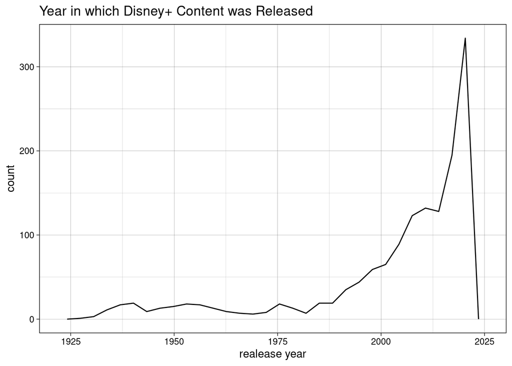

```r
ggplot(disneydata, aes(x = release_year)) +
  geom_freqpoly() +
  theme_linedraw() +
  labs(title = "Year in which Disney+ Content was Released",
       x = "realease year")
```

Create a violin plot of `release_year` (x-axis) grouped by `type` of program (y-axis) for content on Disney+. Fill with a color of your choice. Add a boxplot inside the violin plot, as you did in one of the DataCamp exercises. Re-scale the x-axis so that tick marks appear at whole-decade intervals (e.g., 1980, 1990, 2000). Add an appropriate title and axis labels. Use other formatting as you choose to enhance effectiveness/appearance.

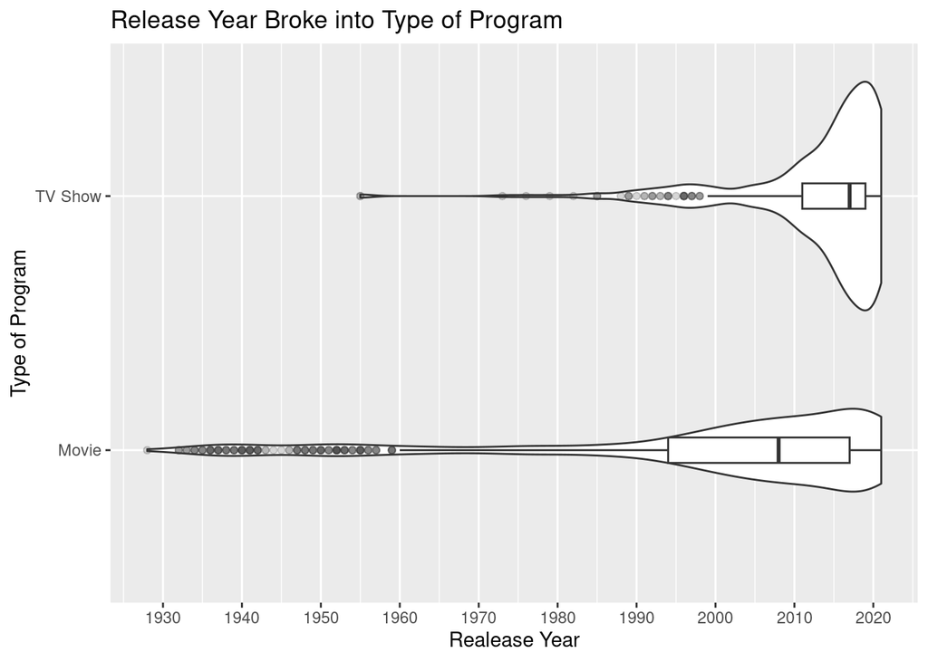

```r
ggplot(disneydata, aes(x = release_year, y = type)) +
  geom_violin() +
  geom_boxplot(width=0.1, alpha=0.2) +
  scale_x_continuous(breaks = seq(1920, 2030, 10)) +
  labs(title = "Release Year Broke into Type of Program",
       x = "Realease Year",
       y = "Type of Program")
```

### Visualization 2: Program Type

**This plot uses the Disney+ Dataset.**

Create a waffle plot (which you learned in DataCamp: [Visualization Best Practices in R](https://app.datacamp.com/learn/courses/visualization-best-practices-in-r)) to display the distribution of program `type` on Disney+.

- Give the plot the title “Streaming Content on Disney+”.
- Change the colors of the squares to something other than the defaults.
- Use an x-axis label to indicate roughly how many programs each square represents.

Hint: Use `round(100 * prop.table(table(DATASETNAME$VARIABLENAME)))` to create the “case_counts” data for the waffle plot. Swap out the capital letter placeholders in the instructions for the correct dataset name and variable name.

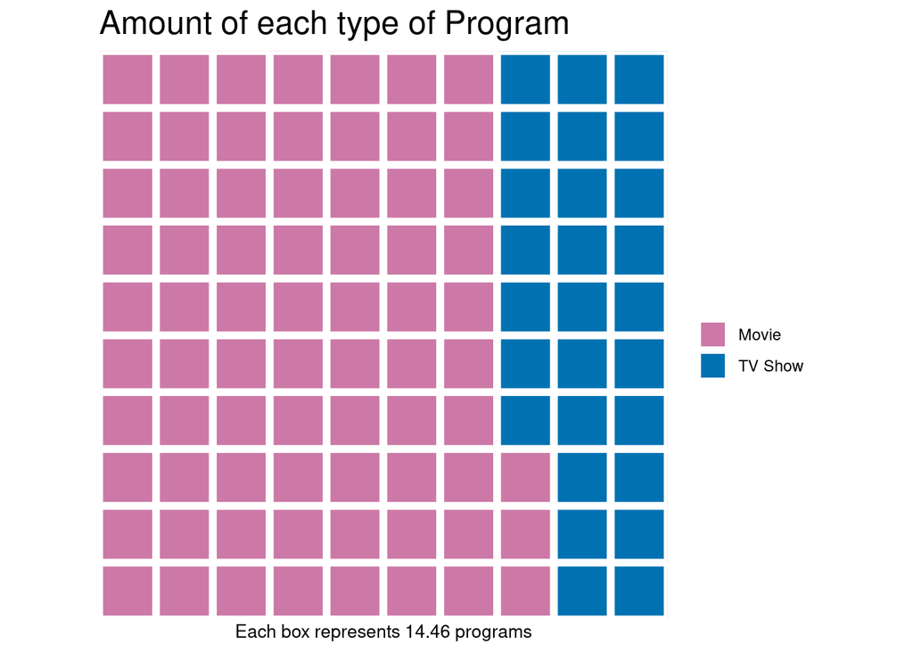

```r
case_counts <- round(100 * prop.table(table(disneydata$type)))
waffle(case_counts, xlab = "Each box represents 14.46 programs", title = "Amount of each type of Program", color = c("#CC79A7", "#0072B2"))
```

### Visualization 3: Choose a Plot!

**This plot uses the Disney+ Dataset.**

Create one other plot of your choice from the Disney+ Dataset to explore a question of interest. You are welcome to perform additional manipulations on the data, if needed. Add an appropriate title and axis labels, as well as any other necessary formatting.

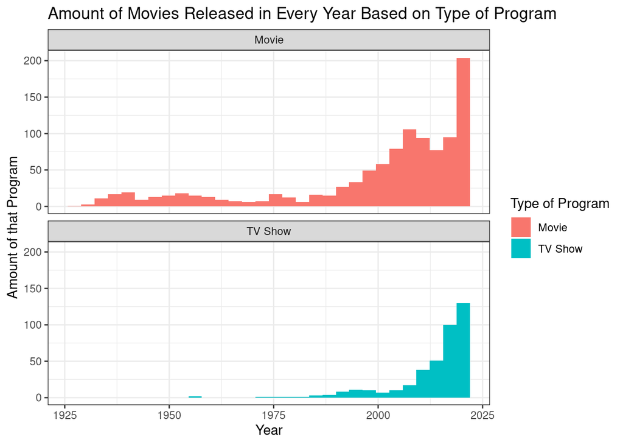

```r
ggplot(disneydata, aes(x = release_year, fill = type)) +
  geom_histogram(bins = 30) +
  theme_bw() +
  facet_wrap(~type, ncol = 1) +
  labs(title = "Amount of Movies Released in Every Year Based on Type of Program",
       x = "Year",
       y = "Amount of that Program",
       fill = "Type of Program")
```

### Visualization 4: Content Volume

**This plot uses the Streaming Dataset.**

Create a barplot to display how many shows are offered on each of the four streaming services. Choose appropriate colors, labels, themes, and/or and other types of formatting that you feel will enhance the meaning or visual appearance of the plot.

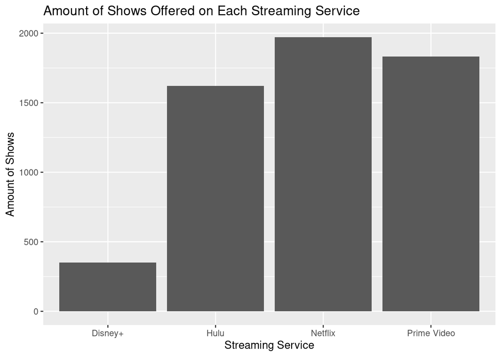

```r
ggplot(newstreamingdata, aes(x = Service)) +
geom_bar() +
  labs(title = "Amount of Shows Offered on Each Streaming Service",
  x = "Streaming Service",
  y = "Amount of Shows")
```

### Visualization 5: Choose a Plot!

**This plot uses the Streaming Dataset.**

Create one other plot of your choice from the Streaming Dataset to explore a question of interest. You are welcome to perform additional manipulations on the data, if needed. Add an appropriate title and axis labels, as well as any other necessary formatting.

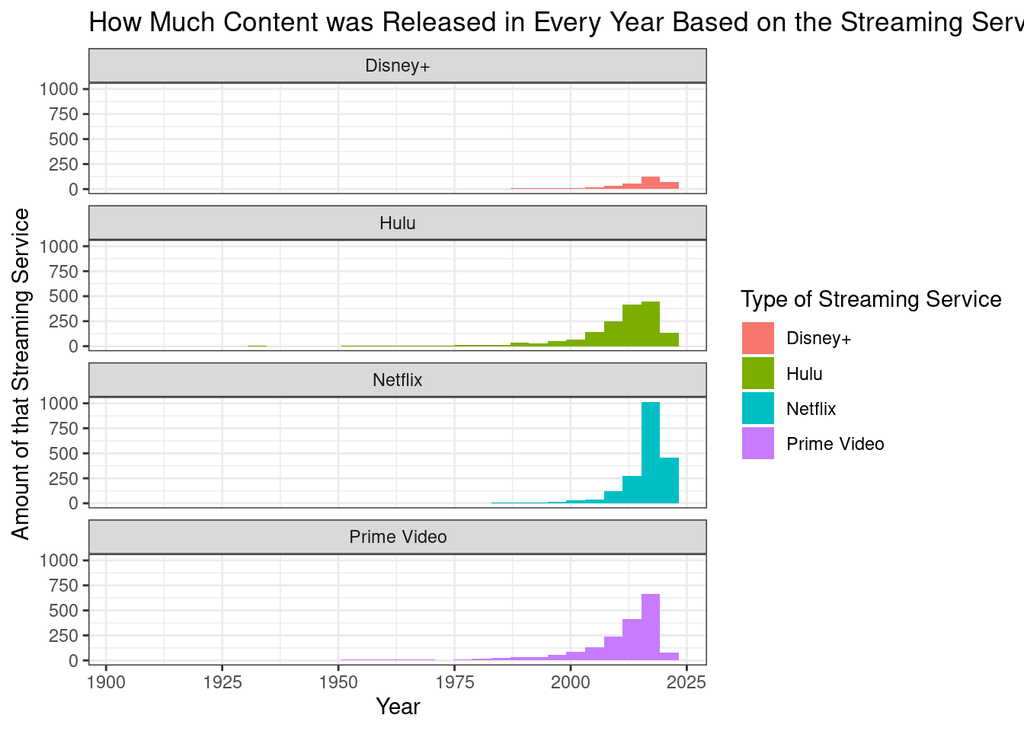

```r
ggplot(newstreamingdata, aes(x = Year, fill = Service)) +
  geom_histogram(bins = 30) +
  theme_bw() +
  facet_wrap(~Service, ncol = 1) +
  labs(title = "How Much Content was Released in Every Year Based on the Streaming Service",
       x = "Year",
       y = "Amount of that Streaming Service",
       fill = "Type of Streaming Service")
```

## Questions

**Question 1:** Based on your plots, make five informational statements or comparisons regarding the Disney+ streaming service.

**Question 2:** What other data would you like to have, or which existing variables would you like to see transformed, if you were going to do further explorations or visualizations? Give at least two examples.

**ANSWER**

I would like to study the percentages of each genre that is on Disney plus compared to other streaming services. I would also like to look at the percent of each rating that is represented on Disney plus.

**Question 3:** Explain the rationale behind the choices you made with regard to plot type, formatting, and so on, when you created Visualizations 3 and 5. Walk me through your process. What motivated your decisions?

**ANSWER** In my visualization 3 I wanted to look at a combination of the first to plots I created. I think seeing the amount of content from each release year was interesting in visualization 1 and I like how in the violin/boxplots split up tv shows and movies. In my visualization three I was able to look at shows and movies separately to see seeing the amount of content from each release year. Visualization five was interesting because it broke up the year and the amount of content on each steaming service.